# hw_3b_Keohane

Isaac Keohane

3/18/2021

```r
library(tidyverse)
library(palmerpenguins)
library(ggiraph)
library(ggiraphExtra)
library(rstatix)
library(gvlma)
```

#### Introduction

I came into this problem of predicting the penguin body masses thinking I was going to apply a multiple regression model. Because the goal here is prediction, I wanted to include all the variables that appeared somewhat correlated to body mass without too much consideration for the specific statistical relationship of each individual independent variable to body mass.

#### Looking at the original data

As usual, I began by just looking at the data overall, just to remind myself which variables we have and how many different levels of each factor variable there are.

```r
glimpse(penguins)
```

```
## Rows: 344
## Columns: 8
## $ species           <fct> Adelie, Adelie, Adelie, Adelie, Adelie, Adelie, Ade…
## $ island            <fct> Torgersen, Torgersen, Torgersen, Torgersen, Torgers…
## $ bill_length_mm    <dbl> 39.1, 39.5, 40.3, NA, 36.7, 39.3, 38.9, 39.2, 34.1,…
## $ bill_depth_mm     <dbl> 18.7, 17.4, 18.0, NA, 19.3, 20.6, 17.8, 19.6, 18.1,…
## $ flipper_length_mm <int> 181, 186, 195, NA, 193, 190, 181, 195, 193, 190, 18…
## $ body_mass_g       <int> 3750, 3800, 3250, NA, 3450, 3650, 3625, 4675, 3475,…
## $ sex               <fct> male, female, female, NA, female, male, female, mal…
## $ year              <int> 2007, 2007, 2007, 2007, 2007, 2007, 2007, 2007, 200…
```

```r
summary(penguins)
```

```
##       species          island    bill_length_mm  bill_depth_mm
##  Adelie   :152   Biscoe   :168   Min.   :32.10   Min.   :13.10
##  Chinstrap: 68   Dream    :124   1st Qu.:39.23   1st Qu.:15.60
##  Gentoo   :124   Torgersen: 52   Median :44.45   Median :17.30
##                                  Mean   :43.92   Mean   :17.15
##                                  3rd Qu.:48.50   3rd Qu.:18.70
##                                  Max.   :59.60   Max.   :21.50
##                                  NA's   :2       NA's   :2
##  flipper_length_mm  body_mass_g       sex           year
##  Min.   :172.0     Min.   :2700   female:165   Min.   :2007
##  1st Qu.:190.0     1st Qu.:3550   male  :168   1st Qu.:2007
##  Median :197.0     Median :4050   NA's  : 11   Median :2008
##  Mean   :200.9     Mean   :4202                Mean   :2008
##  3rd Qu.:213.0     3rd Qu.:4750                3rd Qu.:2009
##  Max.   :231.0     Max.   :6300                Max.   :2009
##  NA's   :2         NA's   :2
```

#### Exploratory data analysis

I took a pretty simple approach to the exploratory data analysis for thinking about developing a predictive model. I knew coming into this problem that I was probably going to go in the direction of a multivariate linear regression model. There are multiple independent variables (flipper length, bill length, bill depth, sex, species, island). I plotted histograms of body mass as a representative physical measurement to see how the distribution of physical traits varied between the categorical variable of species, sex, and island. These histograms show decently normal distributions in body mass, with clearly different means for different sexes and species. This indicated to me that I should include species and sex as categorical variables in the regression model since there is clearly variation in the distributions of body mass between them.

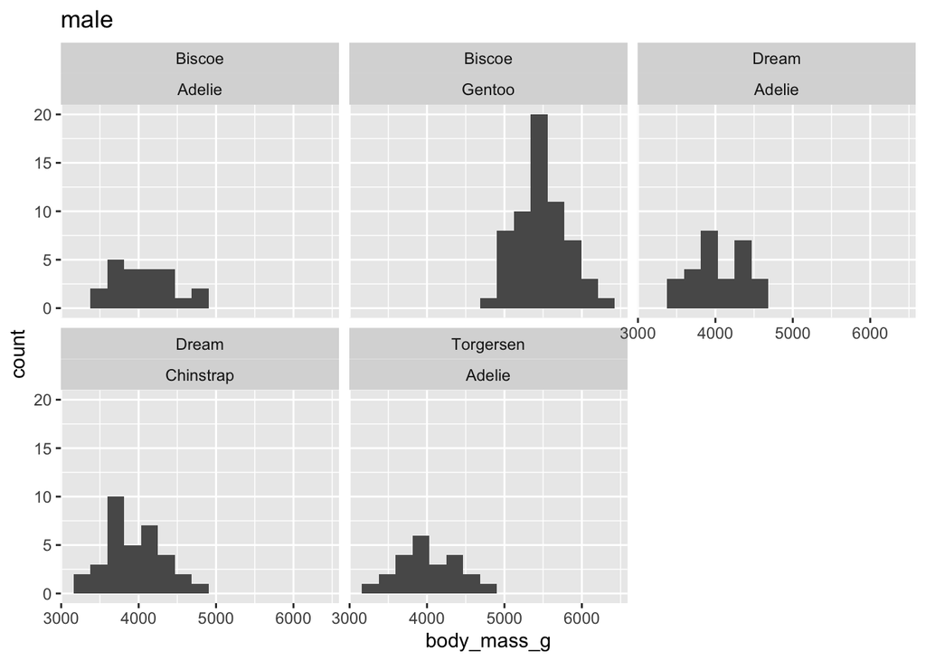

```r
ggplot(aes(x=body_mass_g), data=penguins %>% drop_na() %>% filter(sex=="male")) +
  geom_histogram(bins=15) +
  facet_wrap(island~species) +
  labs(title="male")
```

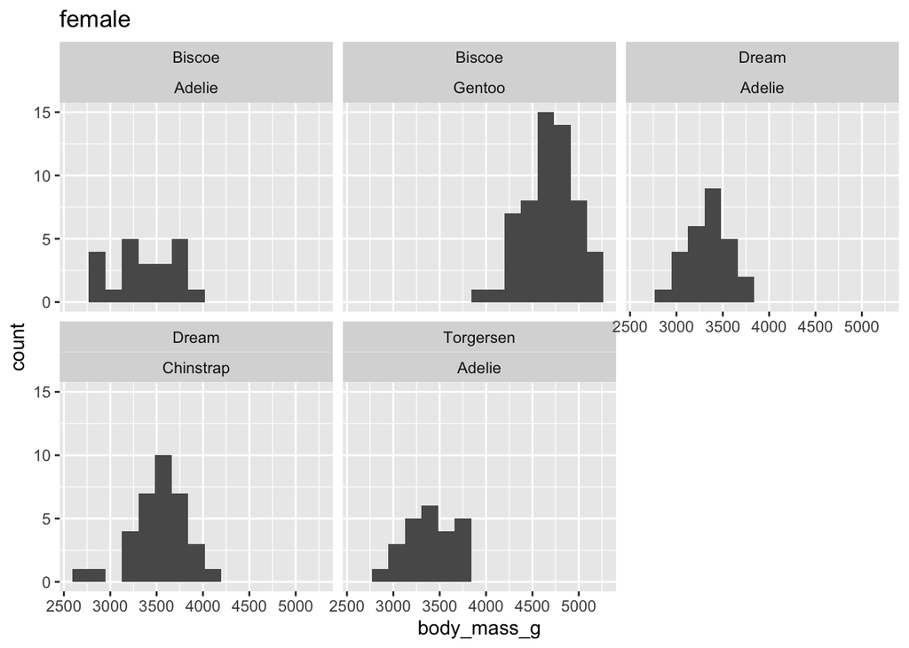

```r
ggplot(aes(x=body_mass_g), data=penguins %>% drop_na() %>% filter(sex=="female")) +
  geom_histogram(bins=15) +
  facet_wrap(island~species) +
  labs(title="female")
```

I couldn’t tell from visually inspecting the histograms if the island variable was causing significant variation, so I applied a t-test to the different island body mass distributions, controlling for a single species and sex. The P values were very large, indicating that there is no evidence island causes different distributions in body mass in this selected data set. Because I could not observe any variation in body mass between the islands, I did not include it as an independent variable in the regression model.

```r
penguins %>% filter(species=="Adelie",sex=="male") %>%
  t_test(body_mass_g ~ island)
```

```
## # A tibble: 3 x 10
##   .y.       group1 group2      n1    n2 statistic    df     p p.adj p.adj.signif
## * <chr>     <chr>  <chr>    <int> <int>     <dbl> <dbl> <dbl> <dbl> <chr>
## 1 body_mas… Biscoe Dream       22    28    0.0454  43.6 0.964     1 ns
## 2 body_mas… Biscoe Torgers…    22    23    0.140   43.0 0.889     1 ns
## 3 body_mas… Dream  Torgers…    28    23    0.108   44.5 0.915     1 ns
```

#### Multiple regression

I wanted to compare a multiple regression model with all of the variables I chose to a simpler one without the use of categorical variables. I used lm to create this, creating one model that was controlled for species and sex (Adelie, male). If this type of model was going to be used for the actual end-user case, one of each of these models would have to be made for each combination of species and sex. I thought that potentially by isolating each population individually, a better relationship between the measurable independent variables and body mass could be found. However, looking at the results of this model, the $R^2$ value is extremely low, suggesting this model is not very accurate. Also, in the summary of this lm, the p value for the coefficients are pretty large, suggesting they are not necessarily statistically significant as indicators of the relationship between the variables and body mass.

```r
data_lm =  penguins %>% drop_na()
lm_multi_noCat = lm(body_mass_g ~ bill_length_mm + bill_depth_mm +
                flipper_length_mm, data=data_lm %>% filter(species=="Adelie",sex=="male"))

summary(lm_multi_noCat)
```

```
##
## Call:
## lm(formula = body_mass_g ~ bill_length_mm + bill_depth_mm + flipper_length_mm,
##     data = data_lm %>% filter(species == "Adelie", sex == "male"))
##
## Residuals:
##     Min      1Q  Median      3Q     Max
## -674.34 -215.06  -14.96  222.39  749.51
##
## Coefficients:
##                   Estimate Std. Error t value Pr(>|t|)
## (Intercept)       -494.767   1299.454  -0.381   0.7046
## bill_length_mm      19.912     17.854   1.115   0.2686
## bill_depth_mm       37.137     38.559   0.963   0.3389
## flipper_length_mm   15.725      6.265   2.510   0.0144 *
## ---
## Signif. codes:  0 '***' 0.001 '**' 0.01 '*' 0.05 '.' 0.1 ' ' 1
##
## Residual standard error: 325.8 on 69 degrees of freedom
## Multiple R-squared:  0.1541, Adjusted R-squared:  0.1173
## F-statistic: 4.189 on 3 and 69 DF,  p-value: 0.008776
```

```r
data_lm_multi_noCat = lm_multi_noCat %>% augment(se_fit=TRUE) %>%
  mutate(lwr = .fitted - 1.96 * .se.fit, upr = .fitted + 1.96 * .se.fit, pred=.fitted)

glimpse(data_lm_multi_noCat %>% select(body_mass_g,pred,lwr,upr))
```

```
## Rows: 73
## Columns: 4
## $ body_mass_g <int> 3750, 3650, 4675, 3800, 4400, 4500, 4200, 3600, 3950, 380…
## $ pred        <dbl> 3824.521, 4040.591, 4080.089, 4064.660, 4091.377, 4218.09…
## $ lwr         <dbl> 3674.383, 3895.612, 3980.507, 3880.181, 3820.955, 4058.05…
## $ upr         <dbl> 3974.658, 4185.569, 4179.672, 4249.139, 4361.799, 4378.14…
```

I then created a new multiple regression model including the categorical variables of sex and species. The resulting $R^2$ value for the predictions was much higher (>.8) and therefore supportive of this model being useful for predicting body mass. Also, the p-values for the coefficients all suggest they are at least somewhat significant (<0.5).

I then used gvlma (global validation of linear model assumptions) to provide some idea of the assumptions in each model. The multiple regression model with the categorical variables, the one with the much better $R^2$, did fail one of the assumption tests: link function. This does make some sense to me as this test looks at continuity in the dependent variable, and because of the discrete sexes and species I wouldn’t expect the output variable to be continuous. I’m sure there is a better type of model to do this prediction that acconts for this specifically, but failing this assumption test did not suprprise me or worry me too much.

```r
lm_multi_wCat = lm(body_mass_g ~ bill_length_mm + bill_depth_mm +
                flipper_length_mm + species + sex, data=data_lm)

summary(lm_multi_wCat)
```

```
##
## Call:
## lm(formula = body_mass_g ~ bill_length_mm + bill_depth_mm + flipper_length_mm +
##     species + sex, data = data_lm)
##
## Residuals:
##     Min      1Q  Median      3Q     Max
## -779.65 -173.18   -9.05  186.61  914.11
##
## Coefficients:
##                    Estimate Std. Error t value Pr(>|t|)
## (Intercept)       -1460.995    571.308  -2.557 0.011002 *
## bill_length_mm       18.204      7.106   2.562 0.010864 *
## bill_depth_mm        67.218     19.742   3.405 0.000745 ***
## flipper_length_mm    15.950      2.910   5.482 8.44e-08 ***
## speciesChinstrap   -251.477     81.079  -3.102 0.002093 **
## speciesGentoo      1014.627    129.561   7.831 6.85e-14 ***
## sexmale             389.892     47.848   8.148 7.97e-15 ***
## ---
## Signif. codes:  0 '***' 0.001 '**' 0.01 '*' 0.05 '.' 0.1 ' ' 1
##
## Residual standard error: 287.3 on 326 degrees of freedom
## Multiple R-squared:  0.875,  Adjusted R-squared:  0.8727
## F-statistic: 380.2 on 6 and 326 DF,  p-value: < 2.2e-16
```

```r
data_lm_multi_wCat = lm_multi_wCat %>% augment(se_fit=TRUE) %>%
  mutate(lwr = .fitted - 1.96 * .se.fit, upr = .fitted + 1.96 * .se.fit, pred=.fitted)

glimpse(data_lm_multi_wCat %>% select(body_mass_g,pred,lwr,upr))
```

```
## Rows: 333
## Columns: 4
## $ body_mass_g <int> 3750, 3800, 3250, 3450, 3650, 3625, 4675, 3200, 3800, 440…
## $ pred        <dbl> 3784.654, 3394.413, 3592.859, 3582.806, 4059.561, 3330.62…
## $ lwr         <dbl> 3696.565, 3326.931, 3513.264, 3493.283, 3970.896, 3257.39…
## $ upr         <dbl> 3872.744, 3461.895, 3672.455, 3672.329, 4148.226, 3403.85…
```

```r
gvlma(lm_multi_noCat)
```

```
##
## Call:
## lm(formula = body_mass_g ~ bill_length_mm + bill_depth_mm + flipper_length_mm,
##     data = data_lm %>% filter(species == "Adelie", sex == "male"))
##
## Coefficients:
##       (Intercept)     bill_length_mm      bill_depth_mm  flipper_length_mm
##           -494.77              19.91              37.14              15.73
##
##
## ASSESSMENT OF THE LINEAR MODEL ASSUMPTIONS
## USING THE GLOBAL TEST ON 4 DEGREES-OF-FREEDOM:
## Level of Significance =  0.05
##
## Call:
##  gvlma(x = lm_multi_noCat)
##
##                      Value p-value                Decision
## Global Stat        1.17775  0.8817 Assumptions acceptable.
## Skewness           0.32094  0.5710 Assumptions acceptable.
## Kurtosis           0.26518  0.6066 Assumptions acceptable.
## Link Function      0.03729  0.8469 Assumptions acceptable.
## Heteroscedasticity 0.55433  0.4566 Assumptions acceptable.
```

```r
gvlma(lm_multi_wCat)
```

```
##
## Call:
## lm(formula = body_mass_g ~ bill_length_mm + bill_depth_mm + flipper_length_mm +
##     species + sex, data = data_lm)
##
## Coefficients:
##       (Intercept)     bill_length_mm      bill_depth_mm  flipper_length_mm
##          -1460.99              18.20              67.22              15.95
##  speciesChinstrap      speciesGentoo            sexmale
##           -251.48            1014.63             389.89
##
##
## ASSESSMENT OF THE LINEAR MODEL ASSUMPTIONS
## USING THE GLOBAL TEST ON 4 DEGREES-OF-FREEDOM:
## Level of Significance =  0.05
##
## Call:
##  gvlma(x = lm_multi_wCat)
##
##                      Value p-value                   Decision
## Global Stat        6.08351  0.1930    Assumptions acceptable.
## Skewness           0.84773  0.3572    Assumptions acceptable.
## Kurtosis           0.02352  0.8781    Assumptions acceptable.
## Link Function      5.14636  0.0233 Assumptions NOT satisfied!
## Heteroscedasticity 0.06590  0.7974    Assumptions acceptable.
```

#### Plotting the model predictions

I applied the model predictions to the original data. Because of the multiple independent variables, it would be impossible to plot the predictions against all variables at once, so I broke these up into 2-d plots across all the different variables. These plots for one helped show that there does appear to be linear relationships between the body-measurable independent variables and body mass. But also, by plotting the predictions as well, they show that the model is producing similar relationships between the variables and body mass as is seen in the data. The one thing I noticed here that I don’t quite get, is that if these orange error bars are supposed to be 95% confidence intervals why do so many of the actual individual data values fall outside those error bars?

Red dots are predictions, black are data, orange error bars are the predictions +- 1.96*se, blue line is linear relationship of the data to x, pink line is linear relationship of the predictions to x.

```
## [1] "x = bill_length_mm"
```

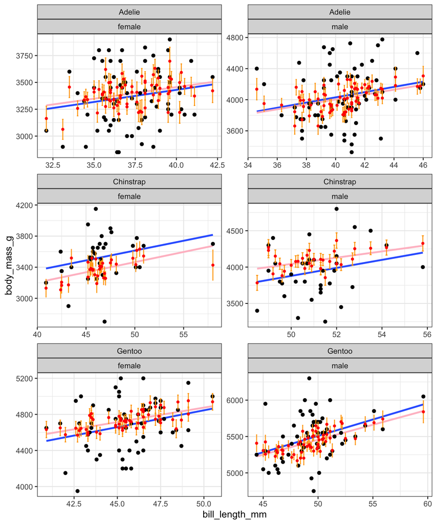

```
## [1] "x = bill_depth_mm"
```

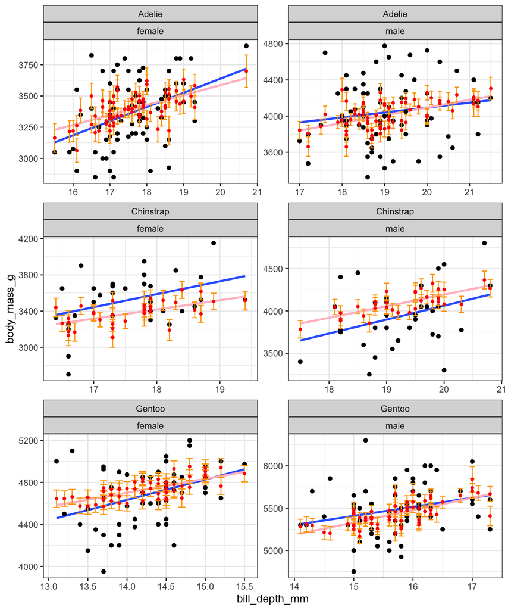

```
## [1] "x = flipper_length_mm"
```

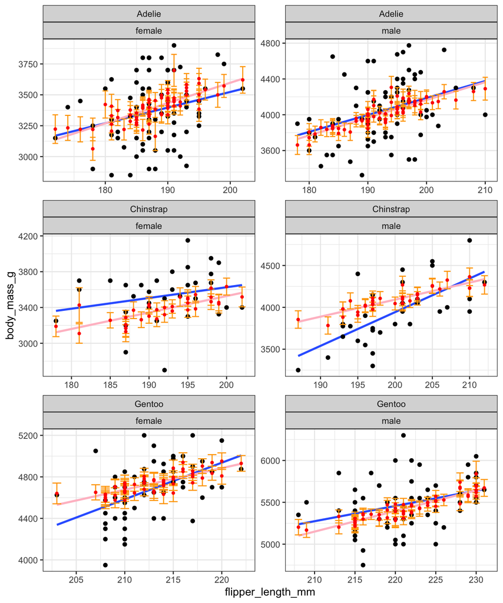

```r
x_cols=c("bill_length_mm", "bill_depth_mm", "flipper_length_mm")
plots = c()
for(col in x_cols){

  myPlot <- ggplot(data=data_lm_multi_wCat,aes_string(x=col)) +
              theme_bw() +
              geom_smooth(aes(y=body_mass_g),method = "lm",se = FALSE) +
              geom_smooth(aes(y=pred),method = "lm",color="pink",se = FALSE) +
              geom_point(aes(y=body_mass_g)) +
              geom_errorbar(aes(ymin=lwr, ymax=upr),color="orange") +
              geom_point(aes(y = pred), color="red", size = 1) +
              facet_wrap(species~sex,ncol=2,scales="free")
  print(paste("x =",col))
  print(myPlot)
}
```

#### Predictions

After looking at the results of this multiple regression and being satisfied by the $R^2$ value and what I observed in the plots, I applied it to the taxidermy data to produce body mass estimates with 1.96*se upper and lower confidence intervals.

```r
data_predict <- read.csv("data/taxidermy_measurements.csv", header=TRUE)

data_predict <- augment(x=lm_multi_wCat,newdata=data_predict,se_fit=TRUE) %>%
  mutate(lwr = .fitted - 1.96 *.se.fit, upr = .fitted + 1.96 * .se.fit, pred=.fitted)

knitr::kable(data_predict %>% select(-c(.fitted,year,.se.fit)))
```

| name | species | island | bill_length_mm | bill_depth_mm | flipper_length_mm | sex | lwr | upr | pred |
| --- | --- | --- | --- | --- | --- | --- | --- | --- | --- |
| MrPopper | Adelie | Torgersen | 41.0 | 19.1 | 179 | male | 3713.368 | 3915.091 | 3814.229 |
| Tacky | Gentoo | Biscoe | 40.9 | 13.8 | 210 | female | 4487.241 | 4663.455 | 4575.348 |
| Hubie | Chinstrap | Dream | 45.9 | 17.2 | 195 | female | 3308.834 | 3470.273 | 3389.553 |